# Explore_dataset_&_model

## Introduction

A stroke is a disease that affects the arteries leading to and within the brain.A stroke occurs when a blood vessel that carries oxygen and nutrients to the brain is either blocked by a clot or bursts.

According to the World Health Organization (WHO) stroke is the 2nd leading cause of death globally, responsible for approximately 11% of total deaths. This dataset is used to predict whether a patient is likely to get stroke based on the input parameters like gender, age, various diseases, and smoking status. Each row in the data provides relavant information about the patient.

#### Dataset Attributes

- id : unique identifier
- gender : "Male", "Female" or "Other"
- age : age of the patient
- hypertension: 0 if the patient doesn't have hypertension, 1 if the patient has hypertension
- heart_disease : 0 if the patient doesn't have any heart diseases, 1 if the patient has a heart disease
- ever_married : "No" or "Yes"
- work_type : "children", "Govt_jov", "Never_worked", "Private" or "Self-employed"
- Residence_type : "Rural" or "Urban"
- avg_glucose_level : average glucose level in blood
- bmi : body mass index
- smoking_status : "formerly smoked", "never smoked", "smokes" or "Unknown"*
- stroke : 1 if the patient had a stroke or 0 if not

## Import Dataset

|  | id | gender | age | hypertension | heart_disease | ever_married | work_type | Residence_type | avg_glucose_level | bmi | smoking_status | stroke |
| --- | --- | --- | --- | --- | --- | --- | --- | --- | --- | --- | --- | --- |
| 0 | 9046 | Male | 67.0 | 0 | 1 | Yes | Private | Urban | 228.69 | 36.6 | formerly smoked | 1 |
| 1 | 51676 | Female | 61.0 | 0 | 0 | Yes | Self-employed | Rural | 202.21 | NaN | never smoked | 1 |
| 2 | 31112 | Male | 80.0 | 0 | 1 | Yes | Private | Rural | 105.92 | 32.5 | never smoked | 1 |
| 3 | 60182 | Female | 49.0 | 0 | 0 | Yes | Private | Urban | 171.23 | 34.4 | smokes | 1 |
| 4 | 1665 | Female | 79.0 | 1 | 0 | Yes | Self-employed | Rural | 174.12 | 24.0 | never smoked | 1 |
| ... | ... | ... | ... | ... | ... | ... | ... | ... | ... | ... | ... | ... |
| 5105 | 18234 | Female | 80.0 | 1 | 0 | Yes | Private | Urban | 83.75 | NaN | never smoked | 0 |
| 5106 | 44873 | Female | 81.0 | 0 | 0 | Yes | Self-employed | Urban | 125.20 | 40.0 | never smoked | 0 |
| 5107 | 19723 | Female | 35.0 | 0 | 0 | Yes | Self-employed | Rural | 82.99 | 30.6 | never smoked | 0 |
| 5108 | 37544 | Male | 51.0 | 0 | 0 | Yes | Private | Rural | 166.29 | 25.6 | formerly smoked | 0 |
| 5109 | 44679 | Female | 44.0 | 0 | 0 | Yes | Govt_job | Urban | 85.28 | 26.2 | Unknown | 0 |

5110 rows × 12 columns

```
<class 'pandas.core.frame.DataFrame'>
RangeIndex: 5110 entries, 0 to 5109
Data columns (total 12 columns):
 #   Column             Non-Null Count  Dtype
---  ------             --------------  -----
 0   id                 5110 non-null   int64
 1   gender             5110 non-null   object
 2   age                5110 non-null   float64
 3   hypertension       5110 non-null   int64
 4   heart_disease      5110 non-null   int64
 5   ever_married       5110 non-null   object
 6   work_type          5110 non-null   object
 7   Residence_type     5110 non-null   object
 8   avg_glucose_level  5110 non-null   float64
 9   bmi                4909 non-null   float64
 10  smoking_status     5110 non-null   object
 11  stroke             5110 non-null   int64
dtypes: float64(3), int64(4), object(5)
memory usage: 479.2+ KB
```

## Data cleaning

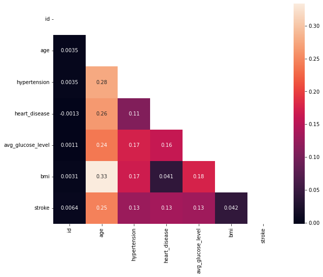

```
id                     0
gender                 0
age                    0
hypertension           0
heart_disease          0
ever_married           0
work_type              0
Residence_type         0
avg_glucose_level      0
bmi                  201
smoking_status         0
stroke                 0
dtype: int64
```

```
Variable : gender
Number of Unique Values : Female    2994
Male      2115
Other        1
Name: gender, dtype: int64
--------------------------------------------------
Variable : ever_married
Number of Unique Values : Yes    3353
No     1757
Name: ever_married, dtype: int64
--------------------------------------------------
Variable : work_type
Number of Unique Values : Private          2925
Self-employed     819
children          687
Govt_job          657
Never_worked       22
Name: work_type, dtype: int64
--------------------------------------------------
Variable : Residence_type
Number of Unique Values : Urban    2596
Rural    2514
Name: Residence_type, dtype: int64
--------------------------------------------------
Variable : smoking_status
Number of Unique Values : never smoked       1892
Unknown            1544
formerly smoked     885
smokes              789
Name: smoking_status, dtype: int64
--------------------------------------------------
```

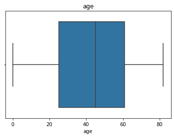

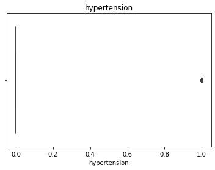

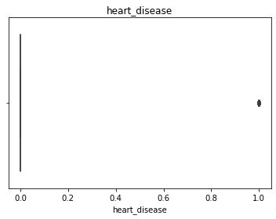

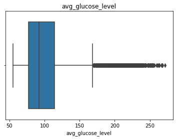

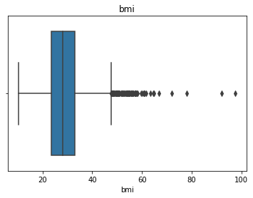

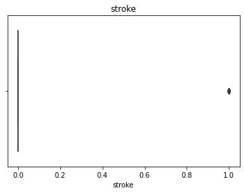

```
id                   0
gender               0
age                  0
hypertension         0
heart_disease        0
ever_married         0
work_type            0
Residence_type       0
avg_glucose_level    0
bmi                  0
smoking_status       0
stroke               0
dtype: int64
```

|  | gender | age | hypertension | heart_disease | ever_married | work_type | Residence_type | avg_glucose_level | bmi | smoking_status | stroke |
| --- | --- | --- | --- | --- | --- | --- | --- | --- | --- | --- | --- |
| 0 | Male | 67.0 | 0 | 1 | Yes | Private | Urban | 228.69 | 36.600000 | formerly smoked | 1 |
| 1 | Female | 61.0 | 0 | 0 | Yes | Self-employed | Rural | 202.21 | 28.893237 | never smoked | 1 |
| 2 | Male | 80.0 | 0 | 1 | Yes | Private | Rural | 105.92 | 32.500000 | never smoked | 1 |
| 3 | Female | 49.0 | 0 | 0 | Yes | Private | Urban | 171.23 | 34.400000 | smokes | 1 |
| 4 | Female | 79.0 | 1 | 0 | Yes | Self-employed | Rural | 174.12 | 24.000000 | never smoked | 1 |
| ... | ... | ... | ... | ... | ... | ... | ... | ... | ... | ... | ... |
| 5105 | Female | 80.0 | 1 | 0 | Yes | Private | Urban | 83.75 | 28.893237 | never smoked | 0 |
| 5106 | Female | 81.0 | 0 | 0 | Yes | Self-employed | Urban | 125.20 | 40.000000 | never smoked | 0 |
| 5107 | Female | 35.0 | 0 | 0 | Yes | Self-employed | Rural | 82.99 | 30.600000 | never smoked | 0 |
| 5108 | Male | 51.0 | 0 | 0 | Yes | Private | Rural | 166.29 | 25.600000 | formerly smoked | 0 |
| 5109 | Female | 44.0 | 0 | 0 | Yes | Govt_job | Urban | 85.28 | 26.200000 | Unknown | 0 |

5110 rows × 11 columns

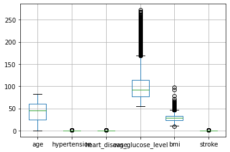

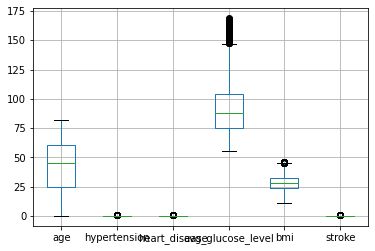

|  | gender | age | hypertension | heart_disease | ever_married | work_type | Residence_type | avg_glucose_level | bmi | smoking_status | stroke |
| --- | --- | --- | --- | --- | --- | --- | --- | --- | --- | --- | --- |
| 0 | 1 | 67.0 | 0 | 1 | 1 | 2 | 1 | NaN | 36.600000 | 1 | 1 |
| 1 | 0 | 61.0 | 0 | 0 | 1 | 3 | 0 | NaN | 28.893237 | 2 | 1 |
| 2 | 1 | 80.0 | 0 | 1 | 1 | 2 | 0 | 105.92 | 32.500000 | 2 | 1 |
| 3 | 0 | 49.0 | 0 | 0 | 1 | 2 | 1 | NaN | 34.400000 | 3 | 1 |
| 4 | 0 | 79.0 | 1 | 0 | 1 | 3 | 0 | NaN | 24.000000 | 2 | 1 |
| ... | ... | ... | ... | ... | ... | ... | ... | ... | ... | ... | ... |
| 5105 | 0 | 80.0 | 1 | 0 | 1 | 2 | 1 | 83.75 | 28.893237 | 2 | 0 |
| 5106 | 0 | 81.0 | 0 | 0 | 1 | 3 | 1 | 125.20 | 40.000000 | 2 | 0 |
| 5107 | 0 | 35.0 | 0 | 0 | 1 | 3 | 0 | 82.99 | 30.600000 | 2 | 0 |
| 5108 | 1 | 51.0 | 0 | 0 | 1 | 2 | 0 | 166.29 | 25.600000 | 1 | 0 |
| 5109 | 0 | 44.0 | 0 | 0 | 1 | 0 | 1 | 85.28 | 26.200000 | 0 | 0 |

5110 rows × 11 columns

```
gender                 0
age                    0
hypertension           0
heart_disease          0
ever_married           0
work_type              0
Residence_type         0
avg_glucose_level    627
bmi                  126
smoking_status         0
stroke                 0
dtype: int64
```

```
gender               0
age                  0
hypertension         0
heart_disease        0
ever_married         0
work_type            0
Residence_type       0
avg_glucose_level    0
bmi                  0
smoking_status       0
stroke               0
dtype: int64
```

### Modelo

```
(5036, 10)
(5036,)
```

### Model and Model Evaluation

#### Decision Tree Classifier

```
              precision    recall  f1-score   support

           0       0.94      0.36      0.52       945
           1       0.06      0.67      0.12        63

    accuracy                           0.38      1008
   macro avg       0.50      0.51      0.32      1008
weighted avg       0.89      0.38      0.50      1008
```

```
<sklearn.metrics._plot.confusion_matrix.ConfusionMatrixDisplay at 0x1f652b17c10>
```

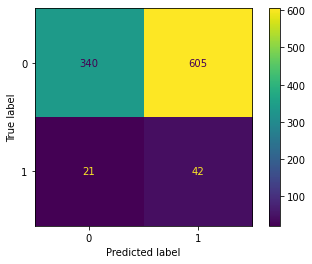

#### Random Forest Classifier

```
              precision    recall  f1-score   support

           0       0.93      0.26      0.41       945
           1       0.06      0.71      0.11        63

    accuracy                           0.29      1008
   macro avg       0.50      0.49      0.26      1008
weighted avg       0.88      0.29      0.39      1008
```

```
<sklearn.metrics._plot.confusion_matrix.ConfusionMatrixDisplay at 0x1f65767f4f0>
```

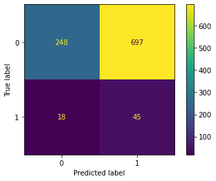

```
array([0.02338321, 0.19784657, 0.07938147, 0.07330038, 0.04515232,
       0.07995155, 0.02294198, 0.22059357, 0.20757897, 0.04986999])
```

#### Logistic Regression

```
              precision    recall  f1-score   support

           0       0.94      0.48      0.64       945
           1       0.07      0.56      0.12        63

    accuracy                           0.49      1008
   macro avg       0.50      0.52      0.38      1008
weighted avg       0.89      0.49      0.61      1008
```

```
<sklearn.metrics._plot.confusion_matrix.ConfusionMatrixDisplay at 0x1f659e1f100>
```

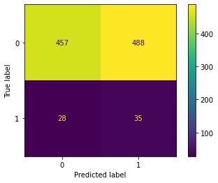

#### SVC

```
              precision    recall  f1-score   support

           0       0.93      0.34      0.50       945
           1       0.06      0.60      0.10        63

    accuracy                           0.36      1008
   macro avg       0.49      0.47      0.30      1008
weighted avg       0.87      0.36      0.47      1008
```

```
<sklearn.metrics._plot.confusion_matrix.ConfusionMatrixDisplay at 0x1f65769d850>
```

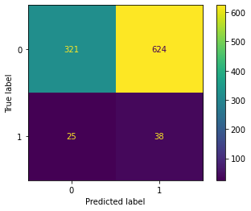

[output not shown]

[output not shown]